# Analysis of leaf traits

Author

Achyut Kumar Banerjee

Published

February 6, 2026

## About the variable

Specific Leaf Area (SLA) and Leaf Dry Matter Content (LDMC) are the two primary indicators of a plant’s position on the **Leaf Economic Spectrum**. They describe how a plant invests its carbon.

### Sampling strategy

> **Hierarchical Sampling Design:** A multi-scale sampling approach was employed to capture the trait plasticity of *Parthenium hysterophorus*. The study followed a nested design: **4 Lakes** (Regional scale) × **3 Habitats** (Landscape scale: Roadside, Abandoned, Natural) × **3 Sites** (Local scale) per combination.

### About Specific Leaf Area

SLA is the ratio of leaf area to leaf dry mass (mm²/mg or cm²/g).

- **Relevance:** It measures the “speed” of a plant’s metabolism.
- **In this study:** High SLA indicates thin, “expensive” leaves that are built for rapid photosynthesis and fast growth. If *Parthenium* shows higher SLA in **Roadside** habitats compared to **Natural** ones, it suggests the weed is switching to an “acquisitive” strategy to exploit the higher light or nutrient availability often found in disturbed areas.

### About Leaf Dry Matter Content (LDMC)

LDMC is the ratio of leaf dry mass to its fresh mass (mg/g).

- **Relevance:** It measures leaf density and “toughness.” It is often inversely related to SLA.
- **In this study:** High LDMC indicates a “conservative” strategy. These leaves are sturdier, better protected against wilting (desiccation), and more resistant to herbivores. If *Parthenium* in **Abandoned** or **Natural** sites has higher LDMC, it suggests the plant is investing in leaf longevity and stress tolerance to survive in more competitive or resource-limited environments.

## About the analysis

With our hierarchical sampling strategy (350 leaves total), we can perform a **Linear Mixed-Effects Model (LMM)**. This is more powerful than a simple ANOVA because it accounts for the fact that leaves collected from the same **Site** are not independent (they share the same soil, micro-climate, and parent plant).

- Summary statistics [mean SLA and LDMC, standard deviation and standard error] - across lakes and habitats Summary statistics
- Linear Mixed-effects Models (LMM) to compare SLA and LDMC values across lakes and habitats

## Install and load packages

```r
library(tidyverse)
library(ggpubr)
library(rstatix)
library(datarium)
library(rstatix)
library(ARTool) # for 2-way ANOVA
library(car) # for the Levene test
library(FSA) # for posthoc test
library(ggplot2) # for plotting
library(Rmisc) # for summary statistics
library(wesanderson) # for plotting
library(lme4)
library(lmerTest) # Adds p-values to lme4 models
library(emmeans)  # For post-hoc comparisons
library(broom.mixed)
library(gt)
library(dplyr)
```

## Set the working directory

```r
setwd("/Users/achyutkumarbanerjee/Library/CloudStorage/OneDrive-AzimPremjiFoundation/Student research/Parthenium summer/partheniumBhopal")
```

## Analysis

### Read data

```r
data<-read.csv("leaf_data.csv")
```

350 observations, 7 variables (Lake, Habitat, Site, Observation, Dry.weight, SLA, LDMC)

### Factorization

Coercing the 2 objects (Lake and Habitat) into factors. The factors will represent categorical data. Factors are useful for statistical modeling and plotting as they treat data as discrete categories rather than continuous numbers or simple characters.

```r
data$group1<-as.factor(data$Lake)
data$group2<-as.factor(data$Habitat)
```

Check the levels of the 2 categorical variables

```r
levels(data$group1)
```

```
[1] "Hathaikheda_Dam" "Kerwa_Dam"       "Lower_Lake"      "Upper_Lake"
```

```r
levels(data$group2)
```

```
[1] "Abandoned" "Natural"   "Roadside"
```

### Summary statistics

We will create 3 vectors each for SLA and LDMC to store the result - one for both the categorical variables together (Lake and Habitat) and two for them separately. For summary statistics, we will use the `summarySE` function of the `Rmisc` package. This function gives count, mean, standard deviation, standard error of the mean, and confidence interval (default 95%).

**Arguments**

- data: a data frame
- measurevar: the name of a column that contains the variable to be summarized
- groupvars: a vector containing names of columns that contain grouping variables

```r
sla <- summarySE(data, measurevar="SLA", groupvars=c("group1","group2"))
sla
```

| group1 | group2 | N | SLA | sd | se | ci |
| --- | --- | --- | --- | --- | --- | --- |
| Hathaikheda_Dam | Abandoned | 30 | 2815.817 | 1206.7457 | 220.3206 | 450.6063 |
| Hathaikheda_Dam | Natural | 30 | 2902.895 | 1625.2456 | 296.7279 | 606.8767 |
| Hathaikheda_Dam | Roadside | 30 | 2356.979 | 1526.4235 | 278.6855 | 569.9759 |
| Kerwa_Dam | Abandoned | 30 | 2107.090 | 986.9425 | 180.1902 | 368.5304 |
| Kerwa_Dam | Natural | 20 | 1988.834 | 1257.0037 | 281.0746 | 588.2959 |
| Kerwa_Dam | Roadside | 30 | 2567.679 | 1169.0769 | 213.4433 | 436.5405 |
| Lower_Lake | Abandoned | 30 | 6237.742 | 1884.4741 | 344.0563 | 703.6742 |
| Lower_Lake | Natural | 30 | 7227.726 | 2553.4764 | 466.1989 | 953.4838 |
| Lower_Lake | Roadside | 30 | 7461.128 | 3057.2451 | 558.1740 | 1141.5941 |
| Upper_Lake | Abandoned | 30 | 3925.185 | 1684.1685 | 307.4857 | 628.8788 |

[output cut: 2 more lines]

```r
ldmc<-summarySE(data, measurevar="LDMC", groupvars=c("group1","group2"))
ldmc
```

| group1 | group2 | N | LDMC | sd | se | ci |
| --- | --- | --- | --- | --- | --- | --- |
| Hathaikheda_Dam | Abandoned | 30 | 0.9039316 | 0.03730905 | 0.006811669 | 0.01393143 |
| Hathaikheda_Dam | Natural | 30 | 0.8918519 | 0.03572109 | 0.006521749 | 0.01333847 |
| Hathaikheda_Dam | Roadside | 30 | 0.9193569 | 0.02631901 | 0.004805172 | 0.00982768 |
| Kerwa_Dam | Abandoned | 30 | 0.9055735 | 0.04076555 | 0.007442737 | 0.01522211 |
| Kerwa_Dam | Natural | 20 | 0.9184304 | 0.02378936 | 0.005319463 | 0.01113376 |
| Kerwa_Dam | Roadside | 30 | 0.9027061 | 0.03625450 | 0.006619136 | 0.01353765 |
| Lower_Lake | Abandoned | 30 | 0.8623822 | 0.04752051 | 0.008676019 | 0.01774445 |
| Lower_Lake | Natural | 30 | 0.8315728 | 0.10331462 | 0.018862582 | 0.03857831 |
| Lower_Lake | Roadside | 30 | 0.8511647 | 0.07449078 | 0.013600094 | 0.02781531 |
| Upper_Lake | Abandoned | 30 | 0.9117781 | 0.07893300 | 0.014411128 | 0.02947407 |

[output cut: 2 more lines]

```r
sla1 <- summarySE(data, measurevar="SLA", groupvars=c("group1"))
sla1
```

| group1 | N | SLA | sd | se | ci |
| --- | --- | --- | --- | --- | --- |
| Hathaikheda_Dam | 90 | 2691.897 | 1467.102 | 154.6461 | 307.2786 |
| Kerwa_Dam | 80 | 2250.247 | 1141.333 | 127.6049 | 253.9912 |
| Lower_Lake | 90 | 6975.532 | 2571.322 | 271.0411 | 538.5529 |
| Upper_Lake | 90 | 5383.579 | 3104.800 | 327.2746 | 650.2877 |

```r
sla2 <- summarySE(data, measurevar="SLA", groupvars=c("group2"))
sla2
```

| group2 | N | SLA | sd | se | ci |
| --- | --- | --- | --- | --- | --- |
| Abandoned | 120 | 3771.458 | 2148.690 | 196.1477 | 388.3920 |
| Natural | 110 | 5322.798 | 3543.063 | 337.8178 | 669.5439 |
| Roadside | 120 | 4137.730 | 2884.579 | 263.3248 | 521.4095 |

```r
ldmc1 <- summarySE(data, measurevar="LDMC", groupvars=c("group1"))
ldmc1
```

| group1 | N | LDMC | sd | se | ci |
| --- | --- | --- | --- | --- | --- |
| Hathaikheda_Dam | 90 | 0.9050468 | 0.03497395 | 0.003686578 | 0.007325151 |
| Kerwa_Dam | 80 | 0.9077124 | 0.03562280 | 0.003982750 | 0.007927466 |
| Lower_Lake | 90 | 0.8483732 | 0.07864995 | 0.008290433 | 0.016472914 |
| Upper_Lake | 90 | 0.8869039 | 0.06613465 | 0.006971204 | 0.013851634 |

```r
ldmc2 <- summarySE(data, measurevar="LDMC", groupvars=c("group2"))
ldmc2
```

| group2 | N | LDMC | sd | se | ci |
| --- | --- | --- | --- | --- | --- |
| Abandoned | 120 | 0.8959164 | 0.05656401 | 0.005163564 | 0.010224373 |
| Natural | 110 | 0.8661402 | 0.07237336 | 0.006900529 | 0.013676625 |
| Roadside | 120 | 0.8955064 | 0.05258644 | 0.004800463 | 0.009505396 |

Summary of the findings:

1. Out of the 4 Lakes, maximum SLA and minimum LDMC = Lower Lake, minimum SLA and maximum LDMC = Kerwa Dam
2. Out of the 3 Habitats, maximum SLA and minimum LDMC = Natural habitat, minimum SLA and maximum LDMC = Abandoned habitat

### Linear Mixed-Effects Model: SLA

```r
# (1|Site) accounts for the nesting of leaves within sites
# We are asking R to separate the noise caused by "Site" differences from the actual signal caused by "Lake" and "Habitat."

sla_model <- lmer(SLA ~ Lake * Habitat + (1|Site), data = data)
summary(sla_model)
```

```
Linear mixed model fit by REML. t-tests use Satterthwaite's method [
lmerModLmerTest]
Formula: SLA ~ Lake * Habitat + (1 | Site)
   Data: data

REML criterion at convergence: 6134.6

Scaled residuals:
    Min      1Q  Median      3Q     Max
-2.8788 -0.6039 -0.1151  0.4195  3.9617

Random effects:
 Groups   Name        Variance Std.Dev.
 Site     (Intercept)  272651   522.2
 Residual             3910332  1977.5
Number of obs: 350, groups:  Site, 3

Fixed effects:
                               Estimate Std. Error       df t value Pr(>|t|)
(Intercept)                    2815.817    470.349    9.205   5.987 0.000188
LakeKerwa_Dam                  -708.727    510.577  335.981  -1.388 0.166029
LakeLower_Lake                 3421.925    510.577  335.981   6.702 8.69e-11
LakeUpper_Lake                 1109.368    510.577  335.981   2.173 0.030496
HabitatNatural                   87.078    510.577  335.981   0.171 0.864682
HabitatRoadside                -458.838    510.577  335.981  -0.899 0.369474
LakeKerwa_Dam:HabitatNatural     76.001    769.280  336.686   0.099 0.921359
LakeLower_Lake:HabitatNatural   902.907    722.065  335.981   1.250 0.212005
LakeUpper_Lake:HabitatNatural  4048.154    722.065  335.981   5.606 4.32e-08
LakeKerwa_Dam:HabitatRoadside   919.427    722.065  335.981   1.273 0.203781
LakeLower_Lake:HabitatRoadside 1682.224    722.065  335.981   2.330 0.020412
LakeUpper_Lake:HabitatRoadside  698.786    722.065  335.981   0.968 0.333860

(Intercept)                    ***
LakeKerwa_Dam
LakeLower_Lake                 ***
LakeUpper_Lake                 *
HabitatNatural
HabitatRoadside
LakeKerwa_Dam:HabitatNatural
LakeLower_Lake:HabitatNatural
```

[output cut: 17 more lines]

```
LkKrw_Dm:HR  0.384 -0.707 -0.354 -0.354 -0.354 -0.707  0.469   0.250   0.250
LkLwr_Lk:HR  0.384 -0.354 -0.707 -0.354 -0.354 -0.707  0.235   0.500   0.250
LkUppr_L:HR  0.384 -0.354 -0.354 -0.707 -0.354 -0.707  0.235   0.250   0.500
            LK_D:HR LL_L:HR
LakeKerw_Dm
LakeLowr_Lk
LakeUppr_Lk
HabitatNtrl
HabitatRdsd
LkKrw_Dm:HN
LkLwr_Lk:HN
LkUppr_L:HN
LkKrw_Dm:HR
LkLwr_Lk:HR  0.500
LkUppr_L:HR  0.500   0.500
```

**Interpretation of the findings**

- **The Random Effects (The “1|Site” part)**

  The table lists “Site” and “Residual.”

  **Interpretation:** This tells us how much of the variation in SLA is due to differences *between* our specific sites versus variation *within* a site (leaf-to-leaf differences).

  **Relevance:** If the variance for “Site” is high, it means that even within the same Lake and Habitat, the specific location (Site) matters a lot—perhaps due to localized soil moisture or shade.

  Variance for the Residual is higher than the Site - specific location does not matter a lot.
- **The Fixed Effects (The “Lake * Habitat” part)**

  The table at the bottom shows the coefficients. Because “Lake” and “Habitat” are categorical, R uses Dummy Coding. This means it picks one category as the “Baseline” (Intercept) and compares everyone else to it.

  **The Intercept**

  What it is: The predicted mean SLA for the reference group (**Hathaikheda_Dam** and **Abandoned** habitat, based on alphabetical order).

  Significance: If the p-value is <0.05, the SLA for this specific baseline group is significantly different from zero (which is expected for biological traits).

  Intercept is significant. The SLA for Parthenium in Abandoned Habitat of Hathaikheda Dam is significantly different from zero.

  **Main Effects (e.g., `LakeLower_Lake` or `HabitatRoadside`)**

  Lake Effect: If `LakeLower_Lake` is positive and significant, it means that in the “Abandoned” habitat, Lower Lake has significantly higher SLA than Hathaikheda Dam.

  Habitat Effect: If `HabitatRoadside` is significant, it means that in Hathaikheda Dam, the Roadside habitat has a different SLA than the Abandoned habitat.
  1. `LakeLower_Lake` is positive and significant = In the “Abandoned” habitat, Lower Lake has significantly higher SLA than Hathaikheda Dam.
  2. `LakeUpper_Lake` is positive and significant = In the “Abandoned” habitat, Upper Lake has significantly higher SLA than Hathaikheda Dam.

  **The Interaction Terms (e.g., `LakeUpper_Lake:HabitatNatural`)**

  This is the most important part for our “plasticity” argument.

  If Significant: It means the way *Parthenium* responds to a habitat depends on which lake it is in. For example, *Parthenium* might increase its SLA on roadsides in the Upper Lake but decrease it on roadsides in Kerwa Dam.

  If NOT Significant: It means *Parthenium* responds to habitats in the same way across all lakes. This suggests a **universal strategy** for the species in this region.
  1. **`LakeUpper_Lake:HabitatNatural`** is significant. It’s not just that Upper Lake has high SLA. It’s not just that Natural habitats have high SLA. It is that **specifically in Upper Lake**, the **Natural habitat** triggers a massive jump in SLA that we don’t see in the Natural habitats of the Dams. Parthenium increases its SLA significantly in natural habitat in the Upper Lake.
  2. The SLA of *Parthenium* in the Natural habitats of Upper Lake (≈8060 mm2/mg) was significantly higher than the baseline (Hathaikheda Dam/Abandoned, ≈2815 mm2/mg). The significant interaction term `LakeUpper_Lake:HabitatNatural` (p<0.05) confirms that this increase represents a unique phenotypic shift toward an acquisitive leaf strategy specifically within the Upper Lake ecosystem.

**Important**

**Summary of the findings:**

#### Tidying up the summary table

```r
tidy(sla_model) %>%
  gt() %>%
  fmt_number(columns = c(estimate, std.error, statistic), decimals = 2) %>%
  fmt_number(columns = p.value, decimals = 4) %>%
  tab_style(
    style = cell_text(size = "small"), # Makes text smaller
    locations = cells_body()
  )
```

| effect | group | term | estimate | std.error | statistic | df | p.value |
| --- | --- | --- | --- | --- | --- | --- | --- |
| fixed | NA | (Intercept) | 2,815.82 | 470.35 | 5.99 | 9.205345 | 0.0002 |
| fixed | NA | LakeKerwa_Dam | −708.73 | 510.58 | −1.39 | 335.981248 | 0.1660 |
| fixed | NA | LakeLower_Lake | 3,421.93 | 510.58 | 6.70 | 335.981248 | 0.0000 |
| fixed | NA | LakeUpper_Lake | 1,109.37 | 510.58 | 2.17 | 335.981248 | 0.0305 |
| fixed | NA | HabitatNatural | 87.08 | 510.58 | 0.17 | 335.981248 | 0.8647 |
| fixed | NA | HabitatRoadside | −458.84 | 510.58 | −0.90 | 335.981248 | 0.3695 |
| fixed | NA | LakeKerwa_Dam:HabitatNatural | 76.00 | 769.28 | 0.10 | 336.686482 | 0.9214 |
| fixed | NA | LakeLower_Lake:HabitatNatural | 902.91 | 722.06 | 1.25 | 335.981248 | 0.2120 |
| fixed | NA | LakeUpper_Lake:HabitatNatural | 4,048.15 | 722.06 | 5.61 | 335.981248 | 0.0000 |
| fixed | NA | LakeKerwa_Dam:HabitatRoadside | 919.43 | 722.06 | 1.27 | 335.981248 | 0.2038 |
| fixed | NA | LakeLower_Lake:HabitatRoadside | 1,682.22 | 722.06 | 2.33 | 335.981248 | 0.0204 |
| fixed | NA | LakeUpper_Lake:HabitatRoadside | 698.79 | 722.06 | 0.97 | 335.981248 | 0.3339 |
| ran_pars | Site | sd__(Intercept) | 522.16 | NA | NA | NA | NA |
| ran_pars | Residual | sd__Observation | 1,977.46 | NA | NA | NA | NA |

#### Posthoc comparisons

To find exactly *where* the differences are. Since the Interaction was significant, we must look at habitats *within* each lake separately.

```r
emmeans(sla_model, pairwise ~ Habitat | Lake)
```

```
$emmeans
Lake = Hathaikheda_Dam:
 Habitat   emmean  SE    df lower.CL upper.CL
 Abandoned   2816 470  9.29     1757     3875
 Natural     2903 470  9.29     1844     3962
 Roadside    2357 470  9.29     1298     3416

Lake = Kerwa_Dam:
 Habitat   emmean  SE    df lower.CL upper.CL
 Abandoned   2107 470  9.29     1048     3166
 Natural     2270 541 15.75     1121     3419
 Roadside    2568 470  9.29     1509     3627

Lake = Lower_Lake:
 Habitat   emmean  SE    df lower.CL upper.CL
 Abandoned   6238 470  9.29     5179     7297
 Natural     7228 470  9.29     6169     8287
 Roadside    7461 470  9.29     6402     8520

Lake = Upper_Lake:
 Habitat   emmean  SE    df lower.CL upper.CL
 Abandoned   3925 470  9.29     2866     4984
 Natural     8060 470  9.29     7001     9119
 Roadside    4165 470  9.29     3106     5224

Degrees-of-freedom method: kenward-roger
Confidence level used: 0.95

$contrasts
Lake = Hathaikheda_Dam:
 contrast             estimate  SE  df t.ratio p.value
 Abandoned - Natural     -87.1 511 336  -0.171  0.9841
 Abandoned - Roadside    458.8 511 336   0.899  0.6415
 Natural - Roadside      545.9 511 336   1.069  0.5339

Lake = Kerwa_Dam:
 contrast             estimate  SE  df t.ratio p.value
 Abandoned - Natural    -163.1 577 337  -0.283  0.9569
 Abandoned - Roadside   -460.6 511 336  -0.902  0.6394
 Natural - Roadside     -297.5 577 337  -0.516  0.8636

Lake = Lower_Lake:
 contrast             estimate  SE  df t.ratio p.value
 Abandoned - Natural    -990.0 511 336  -1.939  0.1294
 Abandoned - Roadside  -1223.4 511 336  -2.396  0.0450
 Natural - Roadside     -233.4 511 336  -0.457  0.8913

Lake = Upper_Lake:
 contrast             estimate  SE  df t.ratio p.value
 Abandoned - Natural   -4135.2 511 336  -8.099  <.0001
 Abandoned - Roadside   -239.9 511 336  -0.470  0.8854
 Natural - Roadside     3895.3 511 336   7.629  <.0001

Degrees-of-freedom method: kenward-roger
P value adjustment: tukey method for comparing a family of 3 estimates
```

#### Visualization

To confirm the interaction visually.

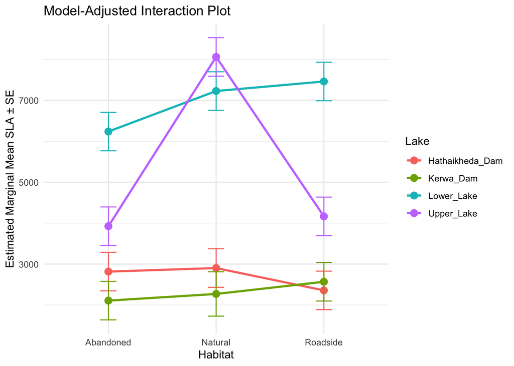

```r
# 1. Extract Adjusted Means from the model
sla_emm <- emmeans(sla_model, ~ Lake * Habitat)

# 2. Convert to data frame for ggplot
sla_emm_df <- as.data.frame(sla_emm)

# 3. Plot using the SE calculated by the model
p1<-ggplot(sla_emm_df, aes(x = Habitat, y = emmean, color = Lake, group = Lake)) +
  geom_line(linewidth = 1) +
  geom_point(size = 3) +
  geom_errorbar(aes(ymin = emmean - SE, ymax = emmean + SE),
                width = 0.15) +
  labs(
    title = "Model-Adjusted Interaction Plot",
    y = "Estimated Marginal Mean SLA ± SE",
    x = "Habitat"
  ) +
  theme_minimal()
p1
```

- We can see the lines for **Kerwa Dam** and **Hathaikheda Dam** being relatively flat and close together (indicating no habitat effect).
- We can see the line for **Upper Lake** “spike” dramatically upward at the “Natural” habitat point, crossing over the other lines.
- **Interpretation:** This “crossing” or non-parallel pattern is the visual proof of our significant **Interaction Effect**. It illustrates that the “Natural” habitat has a unique, stimulating effect on *Parthenium* ONLY in the Upper Lake ecosystem.

### Linear Mixed-Effects Model: LDMC

```r
# (1|Site) accounts for the nesting of leaves within sites
# We are asking R to separate the noise caused by "Site" differences from the actual signal caused by "Lake" and "Habitat."

ldmc_model <- lmer(LDMC ~ Lake * Habitat + (1|Site), data = data)
summary(ldmc_model)
```

```
Linear mixed model fit by REML. t-tests use Satterthwaite's method [
lmerModLmerTest]
Formula: LDMC ~ Lake * Habitat + (1 | Site)
   Data: data

REML criterion at convergence: -962.7

Scaled residuals:
    Min      1Q  Median      3Q     Max
-7.4171 -0.2832  0.0965  0.4265  5.8975

Random effects:
 Groups   Name        Variance  Std.Dev.
 Site     (Intercept) 3.977e-05 0.006306
 Residual             2.994e-03 0.054717
Number of obs: 350, groups:  Site, 3

Fixed effects:
                                 Estimate Std. Error         df t value
(Intercept)                      0.903932   0.010633  48.533923  85.014
LakeKerwa_Dam                    0.001642   0.014128 336.018653   0.116
LakeLower_Lake                  -0.041549   0.014128 336.018653  -2.941
LakeUpper_Lake                   0.007847   0.014128 336.018653   0.555
HabitatNatural                  -0.012080   0.014128 336.018653  -0.855
HabitatRoadside                  0.015425   0.014128 336.018653   1.092
LakeKerwa_Dam:HabitatNatural     0.023241   0.021255 337.792966   1.093
LakeLower_Lake:HabitatNatural   -0.018730   0.019980 336.018653  -0.937
LakeUpper_Lake:HabitatNatural   -0.059563   0.019980 336.018653  -2.981
LakeKerwa_Dam:HabitatRoadside   -0.018293   0.019980 336.018653  -0.916
LakeLower_Lake:HabitatRoadside  -0.026643   0.019980 336.018653  -1.333
LakeUpper_Lake:HabitatRoadside  -0.018406   0.019980 336.018653  -0.921
                               Pr(>|t|)
(Intercept)                     < 2e-16 ***
LakeKerwa_Dam                   0.90755
LakeLower_Lake                  0.00350 **
LakeUpper_Lake                  0.57900
HabitatNatural                  0.39315
HabitatRoadside                 0.27569
LakeKerwa_Dam:HabitatNatural    0.27499
LakeLower_Lake:HabitatNatural   0.34921
```

[output cut: 17 more lines]

```
LkKrw_Dm:HR  0.470 -0.707 -0.354 -0.354 -0.354 -0.707  0.470   0.250   0.250
LkLwr_Lk:HR  0.470 -0.354 -0.707 -0.354 -0.354 -0.707  0.235   0.500   0.250
LkUppr_L:HR  0.470 -0.354 -0.354 -0.707 -0.354 -0.707  0.235   0.250   0.500
            LK_D:HR LL_L:HR
LakeKerw_Dm
LakeLowr_Lk
LakeUppr_Lk
HabitatNtrl
HabitatRdsd
LkKrw_Dm:HN
LkLwr_Lk:HN
LkUppr_L:HN
LkKrw_Dm:HR
LkLwr_Lk:HR  0.500
LkUppr_L:HR  0.500   0.500
```

**Interpretation of the findings**

- **The Random Effects (The “1|Site” part)**

  Variance for the Residual is higher than the Site - specific site does not matter a lot. It means the Lake and Habitat are the true drivers, and the specific site doesn’t matter much.
- **The Fixed Effects (The “Lake * Habitat” part)**

  **The Intercept**

  Intercept is significant. The LDMC for Parthenium in Abandoned Habitat of Hathaikheda Dam is significantly different from zero.

  **Main Effects**
  1. `LakeLower_Lake` is negative and significant = In the “Abandoned” habitat, Lower Lake has significantly lower LDMC than Hathaikheda Dam. Low LDMC means the leaves are more “watery” and less dense. This usually happens when the plant is in a high-resource environment (like the Natural riparian zones of Upper Lake) where it doesn’t need to build “armored,” tough leaves to survive drought. It is focusing on fast growth instead of survival.

#### Tidying up the summary table

```r
tidy(ldmc_model) %>%
  gt() %>%
  fmt_number(columns = c(estimate, std.error, statistic), decimals = 2) %>%
  fmt_number(columns = p.value, decimals = 4) %>%
  tab_style(
    style = cell_text(size = "small"), # Makes text smaller
    locations = cells_body()
  )
```

| effect | group | term | estimate | std.error | statistic | df | p.value |
| --- | --- | --- | --- | --- | --- | --- | --- |
| fixed | NA | (Intercept) | 0.90 | 0.01 | 85.01 | 48.53392 | 0.0000 |
| fixed | NA | LakeKerwa_Dam | 0.00 | 0.01 | 0.12 | 336.01865 | 0.9075 |
| fixed | NA | LakeLower_Lake | −0.04 | 0.01 | −2.94 | 336.01865 | 0.0035 |
| fixed | NA | LakeUpper_Lake | 0.01 | 0.01 | 0.56 | 336.01865 | 0.5790 |
| fixed | NA | HabitatNatural | −0.01 | 0.01 | −0.86 | 336.01865 | 0.3931 |
| fixed | NA | HabitatRoadside | 0.02 | 0.01 | 1.09 | 336.01865 | 0.2757 |
| fixed | NA | LakeKerwa_Dam:HabitatNatural | 0.02 | 0.02 | 1.09 | 337.79297 | 0.2750 |
| fixed | NA | LakeLower_Lake:HabitatNatural | −0.02 | 0.02 | −0.94 | 336.01865 | 0.3492 |
| fixed | NA | LakeUpper_Lake:HabitatNatural | −0.06 | 0.02 | −2.98 | 336.01865 | 0.0031 |
| fixed | NA | LakeKerwa_Dam:HabitatRoadside | −0.02 | 0.02 | −0.92 | 336.01865 | 0.3606 |
| fixed | NA | LakeLower_Lake:HabitatRoadside | −0.03 | 0.02 | −1.33 | 336.01865 | 0.1833 |
| fixed | NA | LakeUpper_Lake:HabitatRoadside | −0.02 | 0.02 | −0.92 | 336.01865 | 0.3576 |
| ran_pars | Site | sd__(Intercept) | 0.01 | NA | NA | NA | NA |
| ran_pars | Residual | sd__Observation | 0.05 | NA | NA | NA | NA |

#### Posthoc comparisons

To find exactly *where* the differences are. Since the Interaction was significant, we must look at habitats *within* each lake separately.

```r
emmeans(ldmc_model, pairwise ~ Habitat | Lake)
```

```
$emmeans
Lake = Hathaikheda_Dam:
 Habitat   emmean     SE   df lower.CL upper.CL
 Abandoned  0.904 0.0106 48.2    0.883    0.925
 Natural    0.892 0.0106 48.2    0.870    0.913
 Roadside   0.919 0.0106 48.2    0.898    0.941

Lake = Kerwa_Dam:
 Habitat   emmean     SE   df lower.CL upper.CL
 Abandoned  0.906 0.0106 48.2    0.884    0.927
 Natural    0.917 0.0130 80.2    0.891    0.943
 Roadside   0.903 0.0106 48.2    0.881    0.924

Lake = Lower_Lake:
 Habitat   emmean     SE   df lower.CL upper.CL
 Abandoned  0.862 0.0106 48.2    0.841    0.884
 Natural    0.832 0.0106 48.2    0.810    0.853
 Roadside   0.851 0.0106 48.2    0.830    0.873

Lake = Upper_Lake:
 Habitat   emmean     SE   df lower.CL upper.CL
 Abandoned  0.912 0.0106 48.2    0.890    0.933
 Natural    0.840 0.0106 48.2    0.819    0.862
 Roadside   0.909 0.0106 48.2    0.887    0.930

Degrees-of-freedom method: kenward-roger
Confidence level used: 0.95

$contrasts
Lake = Hathaikheda_Dam:
 contrast             estimate     SE  df t.ratio p.value
 Abandoned - Natural   0.01208 0.0141 336   0.855  0.6690
 Abandoned - Roadside -0.01543 0.0141 336  -1.092  0.5198
 Natural - Roadside   -0.02751 0.0141 336  -1.947  0.1273

Lake = Kerwa_Dam:
 contrast             estimate     SE  df t.ratio p.value
 Abandoned - Natural  -0.01116 0.0160 338  -0.698  0.7649
 Abandoned - Roadside  0.00287 0.0141 336   0.203  0.9775
 Natural - Roadside    0.01403 0.0160 338   0.877  0.6551

Lake = Lower_Lake:
 contrast             estimate     SE  df t.ratio p.value
 Abandoned - Natural   0.03081 0.0141 336   2.181  0.0760
 Abandoned - Roadside  0.01122 0.0141 336   0.794  0.7070
 Natural - Roadside   -0.01959 0.0141 336  -1.387  0.3490

Lake = Upper_Lake:
 contrast             estimate     SE  df t.ratio p.value
 Abandoned - Natural   0.07164 0.0141 336   5.071  <.0001
 Abandoned - Roadside  0.00298 0.0141 336   0.211  0.9758
 Natural - Roadside   -0.06866 0.0141 336  -4.860  <.0001

Degrees-of-freedom method: kenward-roger
P value adjustment: tukey method for comparing a family of 3 estimates
```

**Interpretation of the findings**

1. **In Upper Lake:** In Upper Lake, habitat type significantly influenced leaf toughness. Specifically, plants in Natural habitats had significantly lower LDMC than those on Roadsides and Abandoned habitats (p<0.001). This is a key biological finding: In Upper Lake, *Parthenium* is extremely “acquisitive” in natural areas, possibly threatening native biodiversity more aggressively there.
2. **In Lower Lake:** The differences are marginally non-significant (p>0.05). LDMC is low everywhere, regardless of habitat.
3. **In Kerwa & Hathaikheda Dams:** There are **no significant differences** between habitats (p>0.05). The plants maintain a steady LDMC across all habitat types.

#### Visualization

To confirm the interaction visually.

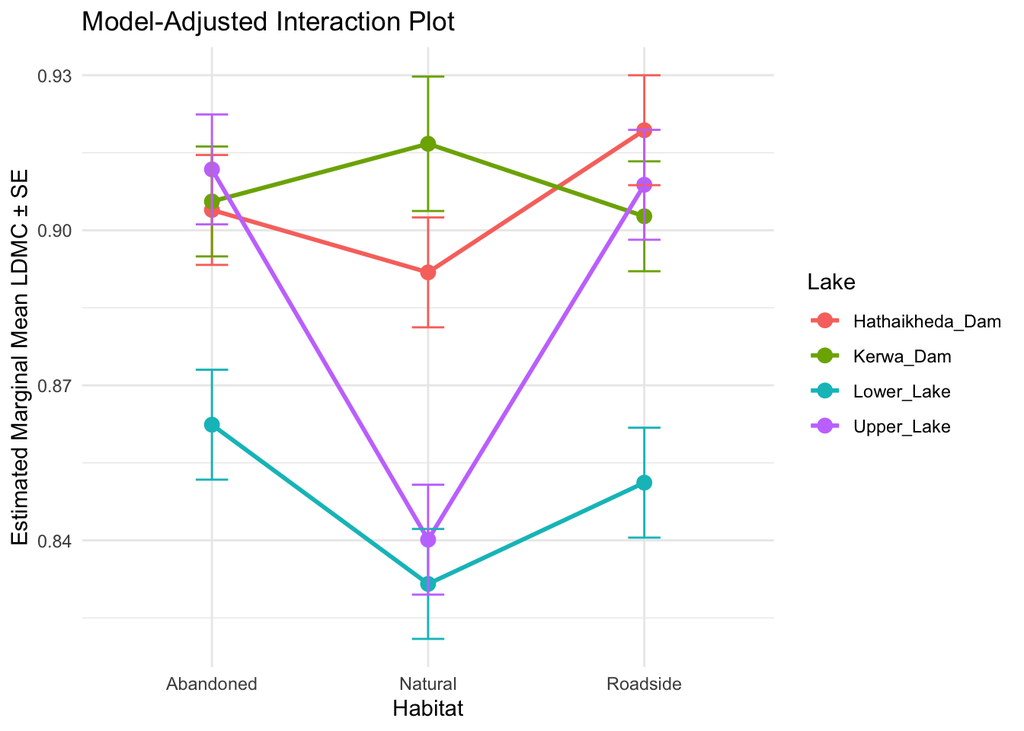

```r
# 1. Extract Adjusted Means from the model
ldmc_emm <- emmeans(ldmc_model, ~ Lake * Habitat)

# 2. Convert to data frame for ggplot
ldmc_emm_df <- as.data.frame(ldmc_emm)

# 3. Plot using the SE calculated by the model
p2<-ggplot(ldmc_emm_df, aes(x = Habitat, y = emmean, color = Lake, group = Lake)) +
  geom_line(linewidth = 1) +
  geom_point(size = 3) +
  geom_errorbar(aes(ymin = emmean - SE, ymax = emmean + SE),
                width = 0.15) +
  labs(
    title = "Model-Adjusted Interaction Plot",
    y = "Estimated Marginal Mean LDMC ± SE",
    x = "Habitat"
  ) +
  theme_minimal()
p2
```

- The sharp decline in LDMC for **Upper Lake** within the **Natural** habitat indicates a shift toward a low-density, acquisitive leaf strategy. In contrast, populations in the dam sites (e.g., Hathaikheda) maintained relatively stable, high LDMC values across all habitats, reflecting a more conservative resource-use strategy. The non-parallel lines visualize the significant Lake × Habitat interaction (p<0.05).
- **Interpretation:** This “crossing” or non-parallel pattern is the visual proof of our significant **Interaction Effect**. It illustrates that the “Natural” habitat has a unique, stimulating effect on *Parthenium* ONLY in the Upper Lake ecosystem.

## Visualization

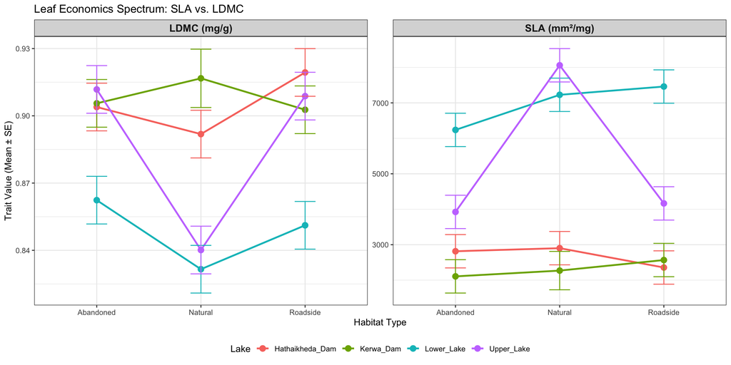

Figure 1: Comparison of SLA and LDMC across habitats

```r
library(dplyr)
library(ggplot2)

# 1. Prepare SLA data
sla_df <- as.data.frame(emmeans(sla_model, ~ Habitat | Lake)) %>%
  mutate(Trait = "SLA (mm²/mg)") # Label it

# 2. Prepare LDMC data
ldmc_df <- as.data.frame(emmeans(ldmc_model, ~ Habitat | Lake)) %>%
  mutate(Trait = "LDMC (mg/g)") # Label it

# 3. Combine them into one big table
all_traits <- rbind(sla_df, ldmc_df)

# 4. Plot using facet_wrap (No extra packages needed!)
ggplot(all_traits, aes(x = Habitat, y = emmean, color = Lake, group = Lake)) +
  geom_line(linewidth = 1) +
  geom_point(size = 3) +
  geom_errorbar(aes(ymin = emmean - SE, ymax = emmean + SE), width = 0.2) +
  # This creates the side-by-side layout
  facet_wrap(~ Trait, scales = "free_y") +
  labs(
    title = "Leaf Economics Spectrum: SLA vs. LDMC",
    y = "Trait Value (Mean ± SE)", # Generic label since units differ
    x = "Habitat Type"
  ) +
  theme_bw() +
  theme(
    strip.text = element_text(size = 12, face = "bold"), # Make titles bigger
    legend.position = "bottom"
  )
```

**Summarizing the leaf trait analysis**

The central discovery of our study is that *Parthenium hysterophorus* does not have a fixed growth strategy. Instead, it exhibits significant **phenotypic plasticity**, meaning it actively adjusts its leaf traits based on the specific combination of regional environment (Lake) and local land use (Habitat).

This is proven statistically by the significant **Lake × Habitat interaction** in both our SLA and LDMC models.

The most dramatic response occurred specifically in the **Natural habitats of Upper Lake**, where *Parthenium* abandoned its “stress-tolerant” baseline in favor of aggressive growth.

- **SLA (Specific Leaf Area):** You found a **significantly positive** interaction.
  - *Result:* Leaves here were much thinner and wider (≈8060 mm2/mg) compared to the baseline (≈2815 mm2/mg).
  - *Strategy:* This maximizes surface area to capture sunlight rapidly, a hallmark of an “acquisitive” or “live fast” strategy.
- **LDMC (Leaf Dry Matter Content):** You found a **significantly negative** interaction.
  - *Result:* Leaves here had much lower dry matter density.
  - *Strategy:* The plant reduced its investment in tough structural tissue (lignin/cellulose), producing “cheaper,” flimsier leaves to save energy for rapid expansion.

Our analysis, thus, confirms the classic **Leaf Economics Spectrum** trade-off. The results for SLA and LDMC act as perfect mirror images of each other:

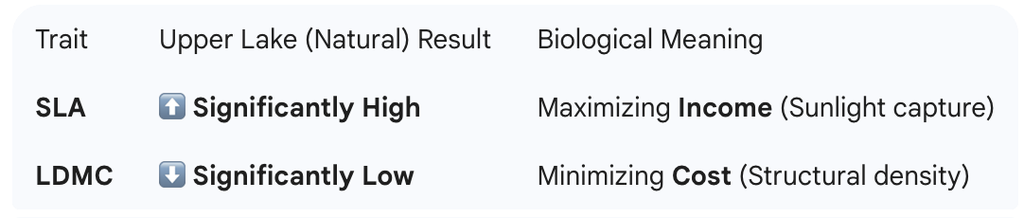

Crucially, this aggressive shift was **context-dependent**.

- **In the Dams (Kerwa/Hathaikheda):** The interaction plots showed relatively flat or parallel lines. *Parthenium* maintained a “conservative” strategy (lower SLA, higher LDMC) even in natural areas.
- **In Upper Lake:** The interaction plots showed “crossing lines” (divergence). The Natural habitat triggered a unique, massive physiological change that did not occur elsewhere.

“Our results demonstrate that *Parthenium hysterophorus* is a highly plastic invader capable of fine-tuning its functional traits to local environmental conditions. In the Upper Lake ecosystem, the plant shifts to a hyper-acquisitive strategy within natural riparian zones—simultaneously increasing SLA and decreasing LDMC to maximize growth rates. In contrast, populations in dam ecosystems maintain a conservative, stress-tolerant strategy regardless of habitat type. This ability to ‘switch gears’ likely contributes to its successful invasion of diverse ecological niches.”